# Feature Selection in Machine Learning (Predicting Breast Cancer)

Shirin Glander

2017-01-13

Machine Learning uses so called features (i.e. variables or attributes) to generate predictive models. Because using too many (unspecific) features for model training poses the problem of overfitting, we generally want to restrict the features in our models to the most repesentative for the response variable. Using a suitable combination of features is essential for obtaining high precision and accuracy of our model.

There are several ways to identify how much each feature contributes to the model and to restrict the number of selected features. Here, I am going to examine:

- Correlation
- Recursive Feature Elimination
- Genetic Algorithm

## Breast Cancer Wisconsin (Diagnostic) Data Set

The data I am going to use to explore feature selection methods is the Breast Cancer Wisconsin (Diagnostic) Data Set:

> W.N. Street, W.H. Wolberg and O.L. Mangasarian. Nuclear feature extraction for breast tumor diagnosis. IS&T/SPIE 1993 International Symposium on Electronic Imaging: Science and Technology, volume 1905, pages 861-870, San Jose, CA, 1993.

> O.L. Mangasarian, W.N. Street and W.H. Wolberg. Breast cancer diagnosis and prognosis via linear programming. Operations Research, 43(4), pages 570-577, July-August 1995.

> W.H. Wolberg, W.N. Street, and O.L. Mangasarian. Machine learning techniques to diagnose breast cancer from fine-needle aspirates. Cancer Letters 77 (1994) 163-171.

> W.H. Wolberg, W.N. Street, and O.L. Mangasarian. Image analysis and machine learning applied to breast cancer diagnosis and prognosis. Analytical and Quantitative Cytology and Histology, Vol. 17 No. 2, pages 77-87, April 1995.

> W.H. Wolberg, W.N. Street, D.M. Heisey, and O.L. Mangasarian. Computerized breast cancer diagnosis and prognosis from fine needle aspirates. Archives of Surgery 1995;130:511-516.

> W.H. Wolberg, W.N. Street, D.M. Heisey, and O.L. Mangasarian. Computer-derived nuclear features distinguish malignant from benign breast cytology. Human Pathology, 26:792–796, 1995.

Included are three datasets. The features in these datasets characterise cell nucleus properties and were generated from image analysis of [fine needle aspirates (FNA)](https://en.wikipedia.org/wiki/Fine-needle_aspiration) of breast masses.

The first datasets encompasses only 9 features, the other two datasets have 30 and 33 features. Here, I want to explore the effect feature selection on model prediction.

### Breast cancer dataset 1

The first dataset looks at the predictor classes:

- M: malignant or
- B: benign breast mass.

The phenotypes for characterisation are:

- Sample ID (code number)
- Clump thickness
- Uniformity of cell size
- Uniformity of cell shape
- Marginal adhesion
- Single epithelial cell size
- Number of bare nuclei
- Bland chromatin
- Number of normal nuclei
- Mitosis
- Classes, i.e. diagnosis

```r
bc_data <- read.table("breast-cancer-wisconsin.data.txt", header = FALSE, sep = ",")
colnames(bc_data) <- c("sample_code_number", "clump_thickness", "uniformity_of_cell_size", "uniformity_of_cell_shape", "marginal_adhesion", "single_epithelial_cell_size",
                       "bare_nuclei", "bland_chromatin", "normal_nucleoli", "mitosis", "classes")
bc_data$classes <- ifelse(bc_data$classes == "2", "benign",
                          ifelse(bc_data$classes == "4", "malignant", NA))

bc_data[bc_data == "?"] <- NA

# how many NAs are in the data
length(which(is.na(bc_data)))
```

```
## [1] 16
```

```r
# impute missing data
library(mice)

bc_data[,2:10] <- apply(bc_data[,2:10], 2, function(x) as.numeric(as.character(x)))
dataset_impute <- mice(bc_data[,2:10],  print = FALSE)
bc_data <- cbind(bc_data[, 11, drop = FALSE], mice::complete(dataset_impute, 1))

str(bc_data)
```

```
## 'data.frame':    699 obs. of  10 variables:
##  $ classes                    : chr  "benign" "benign" "benign" "benign" ...
##  $ clump_thickness            : num  5 5 3 6 4 8 1 2 2 4 ...
##  $ uniformity_of_cell_size    : num  1 4 1 8 1 10 1 1 1 2 ...
##  $ uniformity_of_cell_shape   : num  1 4 1 8 1 10 1 2 1 1 ...
##  $ marginal_adhesion          : num  1 5 1 1 3 8 1 1 1 1 ...
##  $ single_epithelial_cell_size: num  2 7 2 3 2 7 2 2 2 2 ...
##  $ bare_nuclei                : num  1 10 2 4 1 10 10 1 1 1 ...
##  $ bland_chromatin            : num  3 3 3 3 3 9 3 3 1 2 ...
##  $ normal_nucleoli            : num  1 2 1 7 1 7 1 1 1 1 ...
##  $ mitosis                    : num  1 1 1 1 1 1 1 1 5 1 ...
```

### Breast cancer dataset 2

The second dataset looks again at the predictor classes:

- M: malignant or
- B: benign breast mass.

The first two columns give:

- Sample ID
- Classes, i.e. diagnosis

For each cell nucleus, the following ten characteristics were measured:

- Radius (mean of all distances from the center to points on the perimeter)
- Texture (standard deviation of gray-scale values)
- Perimeter
- Area
- Smoothness (local variation in radius lengths)
- Compactness (perimeter^2 / area - 1.0)
- Concavity (severity of concave portions of the contour)
- Concave points (number of concave portions of the contour)
- Symmetry
- Fractal dimension (“coastline approximation” - 1)

For each characteristic three measures are given:

- Mean
- Standard error
- Largest/ “worst”

```r
bc_data_2 <- read.table("wdbc.data.txt", header = FALSE, sep = ",")

phenotypes <- rep(c("radius", "texture", "perimeter", "area", "smoothness", "compactness", "concavity", "concave_points", "symmetry", "fractal_dimension"), 3)
types <- rep(c("mean", "se", "largest_worst"), each = 10)

colnames(bc_data_2) <- c("ID", "diagnosis", paste(phenotypes, types, sep = "_"))

# how many NAs are in the data
length(which(is.na(bc_data_2)))
```

```
## [1] 0
```

```r
str(bc_data_2)
```

```
## 'data.frame':    569 obs. of  32 variables:
##  $ ID                             : int  842302 842517 84300903 84348301 84358402 843786 844359 84458202 844981 84501001 ...
##  $ diagnosis                      : Factor w/ 2 levels "B","M": 2 2 2 2 2 2 2 2 2 2 ...
##  $ radius_mean                    : num  18 20.6 19.7 11.4 20.3 ...
##  $ texture_mean                   : num  10.4 17.8 21.2 20.4 14.3 ...
##  $ perimeter_mean                 : num  122.8 132.9 130 77.6 135.1 ...
##  $ area_mean                      : num  1001 1326 1203 386 1297 ...
##  $ smoothness_mean                : num  0.1184 0.0847 0.1096 0.1425 0.1003 ...
##  $ compactness_mean               : num  0.2776 0.0786 0.1599 0.2839 0.1328 ...
##  $ concavity_mean                 : num  0.3001 0.0869 0.1974 0.2414 0.198 ...
##  $ concave_points_mean            : num  0.1471 0.0702 0.1279 0.1052 0.1043 ...
##  $ symmetry_mean                  : num  0.242 0.181 0.207 0.26 0.181 ...
##  $ fractal_dimension_mean         : num  0.0787 0.0567 0.06 0.0974 0.0588 ...
##  $ radius_se                      : num  1.095 0.543 0.746 0.496 0.757 ...
##  $ texture_se                     : num  0.905 0.734 0.787 1.156 0.781 ...
```

[output cut: 18 more lines]

### Breast cancer dataset 3

The third dataset looks at the predictor classes:

- R: recurring or
- N: nonrecurring breast cancer.

The first two columns give:

- Sample ID
- Classes, i.e. outcome

For each cell nucleus, the same ten characteristics and measures were given as in dataset 2, plus:

- Time (recurrence time if field 2 = R, disease-free time if field 2 = N)
- Tumor size - diameter of the excised tumor in centimeters
- Lymph node status - number of positive axillary lymph nodes observed at time of surgery

```r
bc_data_3 <- read.table("wpbc.data.txt", header = FALSE, sep = ",")
colnames(bc_data_3) <- c("ID", "outcome", "time", paste(phenotypes, types, sep = "_"), "tumor_size", "lymph_node_status")

bc_data_3[bc_data_3 == "?"] <- NA

# how many NAs are in the data
length(which(is.na(bc_data_3)))
```

```
## [1] 4
```

```r
# impute missing data
library(mice)

bc_data_3[,3:35] <- apply(bc_data_3[,3:35], 2, function(x) as.numeric(as.character(x)))
dataset_impute <- mice(bc_data_3[,3:35],  print = FALSE)
bc_data_3 <- cbind(bc_data_3[, 2, drop = FALSE], mice::complete(dataset_impute, 1))

str(bc_data_3)
```

```
## 'data.frame':    198 obs. of  34 variables:
##  $ outcome                        : Factor w/ 2 levels "N","R": 1 1 1 1 2 2 1 2 1 1 ...
##  $ time                           : num  31 61 116 123 27 77 60 77 119 76 ...
##  $ radius_mean                    : num  18 18 21.4 11.4 20.3 ...
##  $ texture_mean                   : num  27.6 10.4 17.4 20.4 14.3 ...
##  $ perimeter_mean                 : num  117.5 122.8 137.5 77.6 135.1 ...
##  $ area_mean                      : num  1013 1001 1373 386 1297 ...
##  $ smoothness_mean                : num  0.0949 0.1184 0.0884 0.1425 0.1003 ...
##  $ compactness_mean               : num  0.104 0.278 0.119 0.284 0.133 ...
##  $ concavity_mean                 : num  0.109 0.3 0.126 0.241 0.198 ...
##  $ concave_points_mean            : num  0.0706 0.1471 0.0818 0.1052 0.1043 ...
##  $ symmetry_mean                  : num  0.186 0.242 0.233 0.26 0.181 ...
##  $ fractal_dimension_mean         : num  0.0633 0.0787 0.0601 0.0974 0.0588 ...
##  $ radius_se                      : num  0.625 1.095 0.585 0.496 0.757 ...
##  $ texture_se                     : num  1.89 0.905 0.611 1.156 0.781 ...
```

[output cut: 20 more lines]

## Principal Component Analysis (PCA)

To get an idea about the dimensionality and variance of the datasets, I am first looking at PCA plots for samples and features.

```r
# preparing plot theme

library(ggplot2)

my_theme <- function(base_size = 12, base_family = "sans"){
  theme_minimal(base_size = base_size, base_family = base_family) +
  theme(
    axis.text = element_text(size = 12),
    axis.text.x = element_text(angle = 45, vjust = 0.5, hjust = 0.5),
    axis.title = element_text(size = 14),
    panel.grid.major = element_line(color = "grey"),
    panel.grid.minor = element_blank(),
    panel.background = element_rect(fill = "aliceblue"),
    strip.background = element_rect(fill = "lightgrey", color = "grey", size = 1),
    strip.text = element_text(face = "bold", size = 12, color = "black"),
    legend.position = "right",
    legend.justification = "top",
    legend.box = "horizontal",
    legend.box.background = element_rect(colour = "grey50"),
    legend.background = element_blank(),
    panel.border = element_rect(color = "grey", fill = NA, size = 0.5)
  )
}

theme_set(my_theme())
```

```r
# preparing function for PCA plotting

library(ellipse)

pca_func <- function(data, groups, title, print_ellipse = TRUE) {
  pcaOutput <- pcaGoPromoter::pca(data, printDropped = FALSE, scale=TRUE, center=TRUE)
  pcaOutput2 <- as.data.frame(pcaOutput$scores)
  pcaOutput2$groups <- groups

  if (print_ellipse) {
    centroids <- aggregate(cbind(PC1, PC2) ~ groups, pcaOutput2, mean)
    conf.rgn  <- do.call(rbind, lapply(unique(pcaOutput2$groups), function(t)
      data.frame(groups = as.character(t),
                 ellipse(cov(pcaOutput2[pcaOutput2$groups == t, 1:2]),
                       centre = as.matrix(centroids[centroids$groups == t, 2:3]),
                       level = 0.95),
                 stringsAsFactors = FALSE)))

    plot <- ggplot(data = pcaOutput2, aes(x = PC1, y = PC2, group = groups, color = groups)) +
      geom_polygon(data = conf.rgn, aes(fill = groups), alpha = 0.2) +
      geom_point(size = 2, alpha = 0.6) +
      scale_colour_brewer(palette = "Set1") +
      labs(title = title,
           color = "",
           fill = "",
           x = paste0("PC1: ", round(pcaOutput$pov[1], digits = 2), "% variance"),
           y = paste0("PC2: ", round(pcaOutput$pov[2], digits = 2), "% variance"))
  } else {

    if (length(unique(pcaOutput2$groups)) <= 10) {
      plot <- ggplot(data = pcaOutput2, aes(x = PC1, y = PC2, group = groups, color = groups)) +
        geom_point(size = 2, alpha = 0.6) +
        scale_colour_brewer(palette = "Set1") +
        labs(title = title,
             color = "",
             fill = "",
             x = paste0("PC1: ", round(pcaOutput$pov[1], digits = 2), "% variance"),
             y = paste0("PC2: ", round(pcaOutput$pov[2], digits = 2), "% variance"))
    } else {
      plot <- ggplot(data = pcaOutput2, aes(x = PC1, y = PC2, group = groups, color = groups)) +
        geom_point(size = 2, alpha = 0.6) +
        labs(title = title,
             color = "",
             fill = "",
             x = paste0("PC1: ", round(pcaOutput$pov[1], digits = 2), "% variance"),
             y = paste0("PC2: ", round(pcaOutput$pov[2], digits = 2), "% variance"))
    }
  }

  return(plot)
}

library(gridExtra)
library(grid)
```

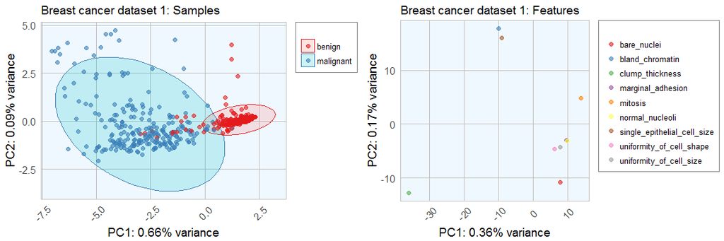

```r
p1 <- pca_func(data = t(bc_data[, 2:10]), groups = as.character(bc_data$classes), title = "Breast cancer dataset 1: Samples")
p2 <- pca_func(data = bc_data[, 2:10], groups = as.character(colnames(bc_data[, 2:10])), title = "Breast cancer dataset 1: Features", print_ellipse = FALSE)
grid.arrange(p1, p2, ncol = 2)
```

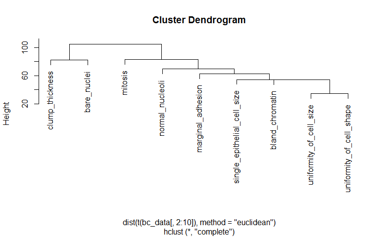

```r
h_1 <- hclust(dist(t(bc_data[, 2:10]), method = "euclidean"))
plot(h_1)
```

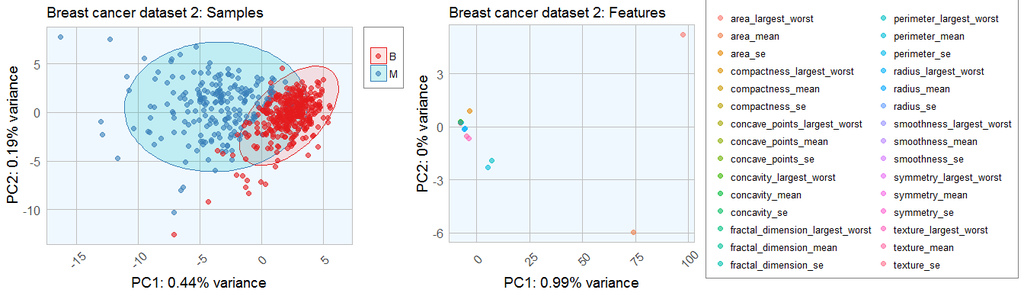

```r
p1 <- pca_func(data = t(bc_data_2[, 3:32]), groups = as.character(bc_data_2$diagnosis), title = "Breast cancer dataset 2: Samples")
p2 <- pca_func(data = bc_data_2[, 3:32], groups = as.character(colnames(bc_data_2[, 3:32])), title = "Breast cancer dataset 2: Features", print_ellipse = FALSE)
grid.arrange(p1, p2, ncol = 2, widths = c(0.4, 0.6))
```

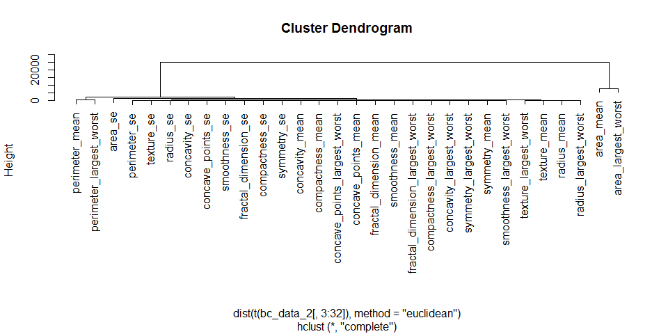

```r
h_2 <- hclust(dist(t(bc_data_2[, 3:32]), method = "euclidean"))
plot(h_2)
```

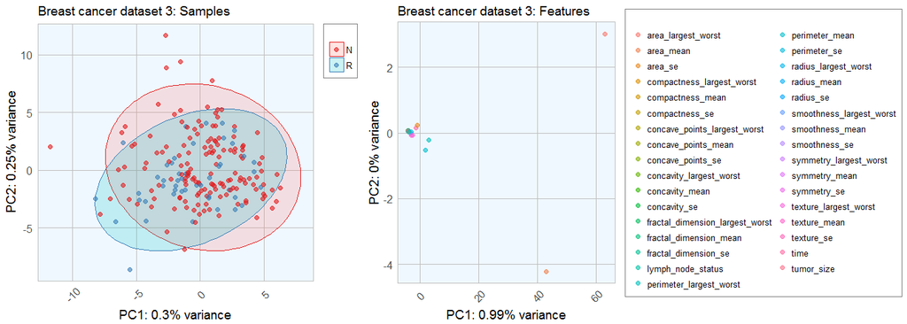

```r
p1 <- pca_func(data = t(bc_data_3[, 2:34]), groups = as.character(bc_data_3$outcome), title = "Breast cancer dataset 3: Samples")
p2 <- pca_func(data = bc_data_3[, 2:34], groups = as.character(colnames(bc_data_3[, 2:34])), title = "Breast cancer dataset 3: Features", print_ellipse = FALSE)
grid.arrange(p1, p2, ncol = 2, widths = c(0.4, 0.6))
```

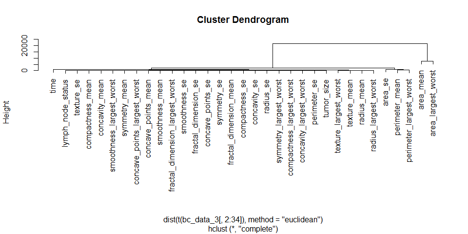

```r
h_3 <- hclust(dist(t(bc_data_3[,2:34]), method = "euclidean"))
plot(h_3)
```

Datasets 1 and 2 show a nice separation of benign and malignant masses, the features will likely be able to predict these classes quite well for most samples. The classes in dataset 3 are mostly overlapping, here I suspect that prediction will not be as accurate.

The features of datasets 2 and 3 don’t cluster very distinctly.

## Feature importance

To get an idea about feature importance I am using a Random Forest algorithm with 10 x 10 cross validation.

```r
library(caret)
library(corrplot)
library(doParallel) # parallel processing
registerDoParallel()

# prepare training scheme
control <- trainControl(method = "repeatedcv", number = 10, repeats = 10)

feature_imp <- function(model, title) {

  # estimate variable importance
  importance <- varImp(model, scale = TRUE)

  importance_df_1 <- importance$importance
  importance_df_1$group <- rownames(importance_df_1)

  importance_df_2 <- importance_df_1
  importance_df_2$Overall <- 0

  importance_df <- rbind(importance_df_1, importance_df_2)

  plot <- ggplot() +
    geom_point(data = importance_df_1, aes(x = Overall, y = group, color = group), size = 2) +
    geom_path(data = importance_df, aes(x = Overall, y = group, color = group, group = group), size = 1) +
    theme(legend.position = "none",
          axis.text.x = element_text(angle = 0, vjust = 0.5, hjust = 0.5)) +
    labs(
      x = "Importance",
      y = "",
      title = title,
      subtitle = "Scaled feature importance",
      caption = "\nDetermined with Random Forest and
      repeated cross validation (10 repeats, 10 times)"
    )
  return(plot)
}
```

```r
# train the model
set.seed(27)
model_1 <- train(classes ~ ., data = bc_data, method = "rf", preProcess = c("scale", "center"), trControl = control)
p1 <- feature_imp(model_1, title = "Breast cancer dataset 1")
```

```r
set.seed(27)
model_2 <- train(diagnosis ~ ., data = bc_data_2[, -1], method = "rf", preProcess = c("scale", "center"), trControl = control)
p2 <- feature_imp(model_2, title = "Breast cancer dataset 2")
```

```r
set.seed(27)
model_3 <- train(outcome ~ ., data = bc_data_3, method = "rf", preProcess = c("scale", "center"), trControl = control)
p3 <- feature_imp(model_3, title = "Breast cancer dataset 3")
```

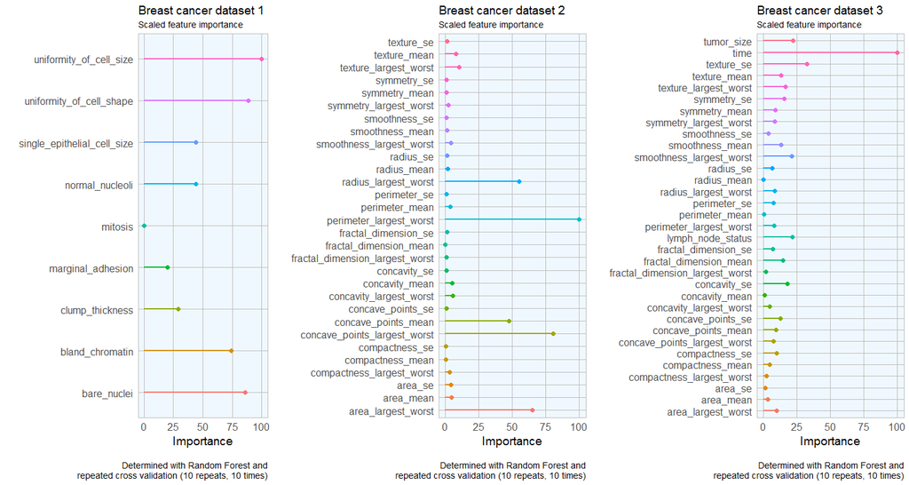

```r
grid.arrange(p1, p2, p3, ncol = 3, widths = c(0.3, 0.35, 0.35))
```

## Correlation

Often we have features that are highly correlated with each other and thus provide redundant information. By eliminating highly correlated features we can avoid a predictive bias for the information contained in these features. When we want to make statements about the importance of specific features, we need to keep in mind that just because they are suitable to predicting an outcome they are not necessarily causal for the outcome - they could simply be highly correlated with causal factors.

- Dataset 1

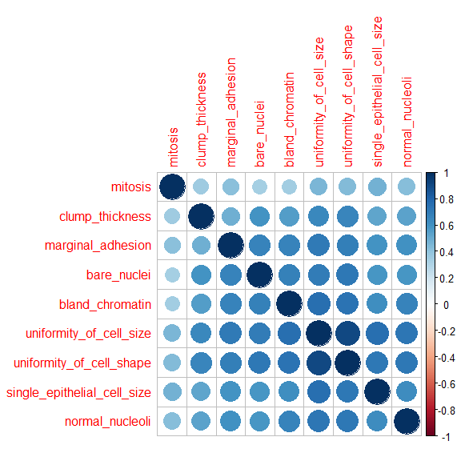

```r
# calculate correlation matrix
corMatMy <- cor(bc_data[,2:10])
corrplot(corMatMy, order = "hclust")
```

```r
#Apply correlation filter at 0.70,
highlyCor <- colnames(bc_data[,2:10])[findCorrelation(corMatMy, cutoff=0.7, verbose = TRUE)]
```

```
## Compare row 2  and column  3 with corr  0.907
##   Means:  0.705 vs 0.59 so flagging column 2
## Compare row 3  and column  7 with corr  0.736
##   Means:  0.667 vs 0.567 so flagging column 3
## All correlations <= 0.7
```

```r
#then we remove these variables
bc_data_cor <- bc_data[, which(!colnames(bc_data) %in% highlyCor)]
```

- Dataset 2

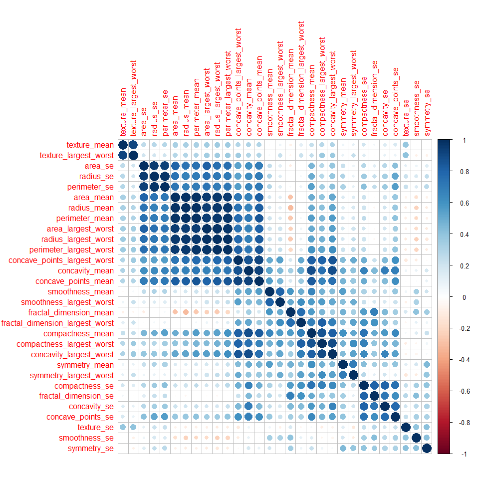

```r
corMatMy <- cor(bc_data_2[,3:32])
corrplot(corMatMy, order = "hclust")
```

```r
highlyCor <- colnames(bc_data_2[,3:32])[findCorrelation(corMatMy, cutoff=0.7, verbose = TRUE)]
```

```
## Compare row 7  and column  8 with corr  0.921
##   Means:  0.571 vs 0.389 so flagging column 7
## Compare row 8  and column  6 with corr  0.831
##   Means:  0.542 vs 0.377 so flagging column 8
## Compare row 6  and column  28 with corr  0.816
##   Means:  0.524 vs 0.365 so flagging column 6
## Compare row 28  and column  27 with corr  0.855
##   Means:  0.507 vs 0.354 so flagging column 28
## Compare row 27  and column  26 with corr  0.892
##   Means:  0.457 vs 0.343 so flagging column 27
## Compare row 23  and column  21 with corr  0.994
##   Means:  0.456 vs 0.333 so flagging column 23
## Compare row 21  and column  3 with corr  0.969
##   Means:  0.422 vs 0.324 so flagging column 21
## Compare row 3  and column  24 with corr  0.942
##   Means:  0.384 vs 0.316 so flagging column 3
## Compare row 26  and column  30 with corr  0.81
##   Means:  0.4 vs 0.313 so flagging column 26
## Compare row 24  and column  1 with corr  0.941
##   Means:  0.356 vs 0.302 so flagging column 24
## Compare row 1  and column  4 with corr  0.987
##   Means:  0.308 vs 0.298 so flagging column 1
## Compare row 4  and column  13 with corr  0.727
##   Means:  0.27 vs 0.294 so flagging column 13
## Compare row 4  and column  11 with corr  0.733
##   Means:  0.244 vs 0.29 so flagging column 11
## Compare row 4  and column  14 with corr  0.8
##   Means:  0.213 vs 0.294 so flagging column 14
## Compare row 18  and column  16 with corr  0.744
##   Means:  0.36 vs 0.292 so flagging column 18
## Compare row 16  and column  17 with corr  0.801
##   Means:  0.394 vs 0.288 so flagging column 16
## Compare row 17  and column  20 with corr  0.727
##   Means:  0.292 vs 0.272 so flagging column 17
## Compare row 5  and column  25 with corr  0.805
##   Means:  0.33 vs 0.268 so flagging column 5
## Compare row 10  and column  30 with corr  0.767
##   Means:  0.372 vs 0.256 so flagging column 10
## Compare row 22  and column  2 with corr  0.912
##   Means:  0.253 vs 0.243 so flagging column 22
## All correlations <= 0.7
```

```r
bc_data_2_cor <- bc_data_2[, which(!colnames(bc_data_2) %in% highlyCor)]
```

- Dataset 3

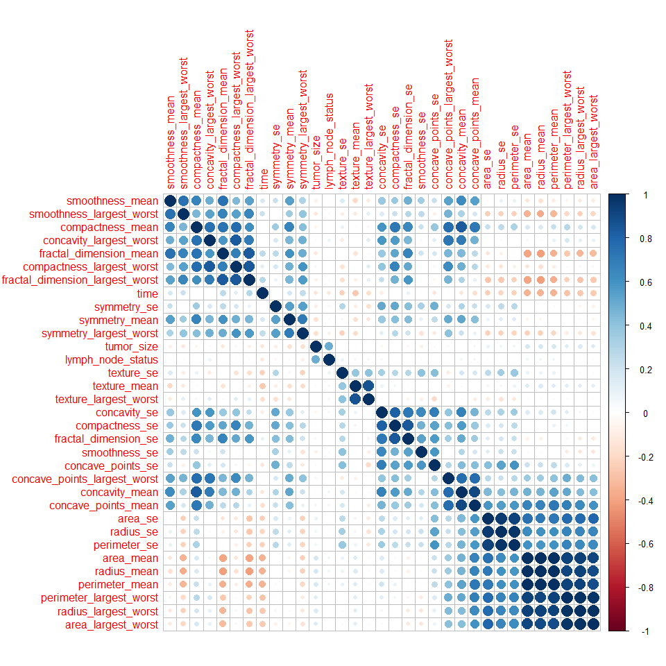

```r
corMatMy <- cor(bc_data_3[,2:34])
corrplot(corMatMy, order = "hclust")
```

```r
highlyCor <- colnames(bc_data_3[,2:34])[findCorrelation(corMatMy, cutoff=0.7, verbose = TRUE)]
```

```
## Compare row 8  and column  9 with corr  0.91
##   Means:  0.424 vs 0.287 so flagging column 8
## Compare row 9  and column  7 with corr  0.716
##   Means:  0.391 vs 0.279 so flagging column 9
## Compare row 7  and column  11 with corr  0.735
##   Means:  0.366 vs 0.272 so flagging column 7
## Compare row 11  and column  31 with corr  0.839
##   Means:  0.352 vs 0.266 so flagging column 11
## Compare row 29  and column  28 with corr  0.726
##   Means:  0.318 vs 0.263 so flagging column 29
## Compare row 4  and column  5 with corr  0.991
##   Means:  0.345 vs 0.255 so flagging column 4
## Compare row 5  and column  2 with corr  0.993
##   Means:  0.324 vs 0.249 so flagging column 5
## Compare row 2  and column  15 with corr  0.711
##   Means:  0.297 vs 0.243 so flagging column 2
## Compare row 14  and column  15 with corr  0.93
##   Means:  0.32 vs 0.239 so flagging column 14
## Compare row 15  and column  24 with corr  0.776
##   Means:  0.276 vs 0.235 so flagging column 15
## Compare row 31  and column  27 with corr  0.847
##   Means:  0.32 vs 0.228 so flagging column 31
## Compare row 24  and column  22 with corr  0.986
##   Means:  0.206 vs 0.223 so flagging column 22
## Compare row 24  and column  25 with corr  0.974
##   Means:  0.167 vs 0.227 so flagging column 25
## Compare row 18  and column  21 with corr  0.717
##   Means:  0.341 vs 0.225 so flagging column 18
## Compare row 21  and column  17 with corr  0.845
##   Means:  0.306 vs 0.212 so flagging column 21
## Compare row 6  and column  26 with corr  0.745
##   Means:  0.27 vs 0.204 so flagging column 6
## Compare row 27  and column  28 with corr  0.835
##   Means:  0.251 vs 0.197 so flagging column 27
## Compare row 10  and column  30 with corr  0.705
##   Means:  0.247 vs 0.188 so flagging column 10
## Compare row 3  and column  23 with corr  0.862
##   Means:  0.163 vs 0.185 so flagging column 23
## All correlations <= 0.7
```

```r
bc_data_3_cor <- bc_data_3[, which(!colnames(bc_data_3) %in% highlyCor)]
```

## Recursive Feature Elimination (RFE)

RFE uses a Random Forest algorithm to test combinations of features and rates each with an accuracy score. The combination with the highest score is usually preferential.

- Dataset 1

```r
# ensure the results are repeatable
set.seed(7)
# define the control using a random forest selection function with cross validation
control <- rfeControl(functions = rfFuncs, method = "cv", number = 10)

# run the RFE algorithm
results_1 <- rfe(x = bc_data[,-1], y = as.factor(bc_data$classes), sizes = c(1:9), rfeControl = control)
```

```r
# summarize the results
print(results_1)
```

```
##
## Recursive feature selection
##
## Outer resampling method: Cross-Validated (10 fold)
##
## Resampling performance over subset size:
##
##  Variables Accuracy  Kappa AccuracySD KappaSD Selected
##          1   0.8884 0.7477    0.04256 0.10498
##          2   0.9400 0.8659    0.03189 0.07175
##          3   0.9628 0.9178    0.02052 0.04539
##          4   0.9542 0.8984    0.02129 0.04788
##          5   0.9570 0.9049    0.02158 0.04859
##          6   0.9642 0.9209    0.02371 0.05302
##          7   0.9685 0.9303    0.02425 0.05443
##          8   0.9699 0.9335    0.02296 0.05153        *
##          9   0.9671 0.9271    0.02044 0.04609
##
## The top 5 variables (out of 8):
##    bare_nuclei, clump_thickness, uniformity_of_cell_size, bland_chromatin, uniformity_of_cell_shape
```

```r
# subset the chosen features
bc_data_rfe <- bc_data[, c(1, which(colnames(bc_data) %in% predictors(results_1)))]
```

- Dataset 2

```r
set.seed(7)
results_2 <- rfe(x = bc_data_2[,-c(1, 2)], y = as.factor(bc_data_2$diagnosis), sizes = c(1:30), rfeControl = control)
```

```r
print(results_2)
```

```
##
## Recursive feature selection
##
## Outer resampling method: Cross-Validated (10 fold)
##
## Resampling performance over subset size:
##
##  Variables Accuracy  Kappa AccuracySD KappaSD Selected
##          1   0.8700 0.7220    0.05857 0.12441
##          2   0.9419 0.8737    0.03542 0.07839
##          3   0.9367 0.8638    0.03230 0.07037
##          4   0.9350 0.8608    0.03319 0.07125
##          5   0.9542 0.9018    0.02379 0.05143
##          6   0.9577 0.9086    0.02904 0.06328
##          7   0.9560 0.9054    0.02380 0.05172
```

[output cut: 26 more lines]

```r
bc_data_2_rfe <- bc_data_2[, c(2, which(colnames(bc_data_2) %in% predictors(results_2)))]
```

- Dataset 3

```r
set.seed(7)
results_3 <- rfe(x = bc_data_3[,-1], y = as.factor(bc_data_3$outcome), sizes = c(1:33), rfeControl = control)
```

```r
print(results_3)
```

```
##
## Recursive feature selection
##
## Outer resampling method: Cross-Validated (10 fold)
##
## Resampling performance over subset size:
##
##  Variables Accuracy     Kappa AccuracySD KappaSD Selected
##          1   0.6767 -0.011822    0.08586  0.1937
##          2   0.6927  0.006927    0.04349  0.1162
##          3   0.7422  0.110225    0.06485  0.2424
##          4   0.7475  0.097453    0.05776  0.2264
##          5   0.7475  0.103706    0.04780  0.2119
##          6   0.7780  0.212319    0.05876  0.2315
##          7   0.7788  0.218525    0.06483  0.2308
```

[output cut: 29 more lines]

```r
bc_data_3_rfe <- bc_data_3[, c(1, which(colnames(bc_data_3) %in% predictors(results_3)))]
```

## Genetic Algorithm (GA)

For demonstration purposes I am using only 10 generations consisting of 5 individuals. More iterations with larger populations would of course be preferable, but this takes quite long to run!

```r
library(dplyr)
library(pROC) # plot the ROC curve

registerDoParallel(8) # Registrer a parallel backend

ga_ctrl <- gafsControl(functions = rfGA, # Assess fitness with RF
                       method = "cv",    # 10 fold cross validation
                       genParallel = TRUE, # Use parallel programming
                       allowParallel = TRUE)
```

- Dataset 1

```r
lev <- c("malignant", "benign")     # Set the levels

set.seed(27)
model_1 <- gafs(x = bc_data[, -1], y = as.factor(bc_data$classes),
                   iters = 10, # generations of algorithm
                   popSize = 5, # population size for each generation
                   levels = lev,
                   gafsControl = ga_ctrl)
```

```r
model_1
```

```
##
## Genetic Algorithm Feature Selection
##
## 699 samples
## 9 predictors
## 2 classes: 'benign', 'malignant'
##
## Maximum generations: 10
## Population per generation: 5
## Crossover probability: 0.8
## Mutation probability: 0.1
## Elitism: 0
##
## Internal performance values: Accuracy, Kappa
## Subset selection driven to maximize internal Accuracy
##
## External performance values: Accuracy, Kappa
## Best iteration chose by maximizing external Accuracy
## External resampling method: Cross-Validated (10 fold)
##
## During resampling:
##   * the top 5 selected variables (out of a possible 9):
##     bare_nuclei (90%), clump_thickness (90%), mitosis (90%), normal_nucleoli (90%), single_epithelial_cell_size (90%)
##   * on average, 7.6 variables were selected (min = 6, max = 8)
##
## In the final search using the entire training set:
##    * 7 features selected at iteration 2 including:
##      clump_thickness, uniformity_of_cell_size, marginal_adhesion, single_epithelial_cell_size, bare_nuclei ...
##    * external performance at this iteration is
##
##    Accuracy       Kappa
##      0.9728      0.9405
```

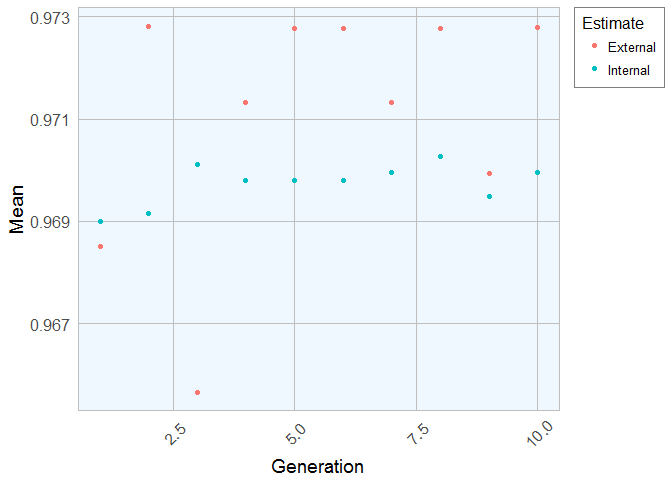

```r
plot(model_1) # Plot mean fitness (AUC) by generation
```

```r
bc_data_ga <- bc_data[, c(1, which(colnames(bc_data) %in% model_1$ga$final))]
```

- Dataset 2

```r
lev <- c("M", "B")

set.seed(27)
model_2 <- gafs(x = bc_data_2[, -c(1, 2)], y = as.factor(bc_data_2$diagnosis),
                   iters = 10, # generations of algorithm
                   popSize = 5, # population size for each generation
                   levels = lev,
                   gafsControl = ga_ctrl)
```

```r
model_2
```

```
##
## Genetic Algorithm Feature Selection
##
## 569 samples
## 30 predictors
## 2 classes: 'B', 'M'
##
## Maximum generations: 10
## Population per generation: 5
## Crossover probability: 0.8
## Mutation probability: 0.1
## Elitism: 0
##
## Internal performance values: Accuracy, Kappa
## Subset selection driven to maximize internal Accuracy
##
## External performance values: Accuracy, Kappa
## Best iteration chose by maximizing external Accuracy
## External resampling method: Cross-Validated (10 fold)
##
## During resampling:
##   * the top 5 selected variables (out of a possible 30):
##     texture_largest_worst (100%), perimeter_mean (90%), concave_points_largest_worst (80%), fractal_dimension_se (80%), radius_largest_worst (80%)
##   * on average, 18.4 variables were selected (min = 11, max = 28)
##
## In the final search using the entire training set:
##    * 25 features selected at iteration 7 including:
##      radius_mean, texture_mean, perimeter_mean, area_mean, smoothness_mean ...
##    * external performance at this iteration is
##
##    Accuracy       Kappa
##      0.9719      0.9393
```

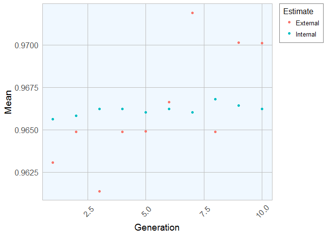

```r
plot(model_2)
```

```r
bc_data_2_ga <- bc_data_2[, c(2, which(colnames(bc_data_2) %in% model_2$ga$final))]
```

- Dataset 3

```r
lev <- c("R", "N")

set.seed(27)
model_3 <- gafs(x = bc_data_3[, -1], y = as.factor(bc_data_3$outcome),
                   iters = 10, # generations of algorithm
                   popSize = 5, # population size for each generation
                   levels = lev,
                   gafsControl = ga_ctrl)
```

```r
model_3
```

```
##
## Genetic Algorithm Feature Selection
##
## 198 samples
## 33 predictors
## 2 classes: 'N', 'R'
##
## Maximum generations: 10
## Population per generation: 5
## Crossover probability: 0.8
## Mutation probability: 0.1
## Elitism: 0
##
## Internal performance values: Accuracy, Kappa
## Subset selection driven to maximize internal Accuracy
##
## External performance values: Accuracy, Kappa
## Best iteration chose by maximizing external Accuracy
## External resampling method: Cross-Validated (10 fold)
##
## During resampling:
##   * the top 5 selected variables (out of a possible 33):
##     area_mean (100%), concavity_se (100%), fractal_dimension_mean (100%), radius_mean (100%), texture_mean (100%)
##   * on average, 27.1 variables were selected (min = 24, max = 30)
##
## In the final search using the entire training set:
##    * 17 features selected at iteration 4 including:
##      time, smoothness_mean, compactness_mean, concave_points_mean, symmetry_mean ...
##    * external performance at this iteration is
##
##    Accuracy       Kappa
##      0.8281      0.3477
```

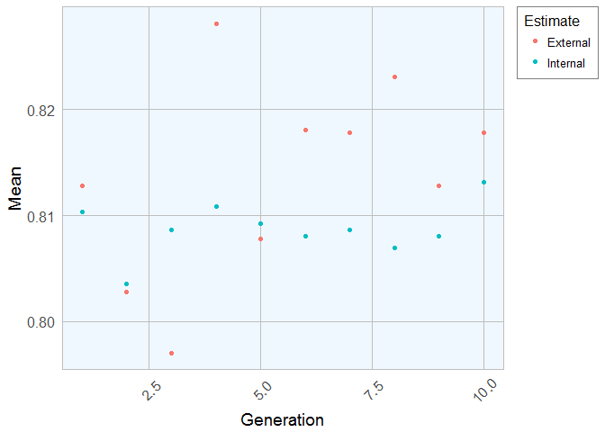

```r
plot(model_3)
```

```r
bc_data_3_ga <- bc_data_3[, c(1, which(colnames(bc_data_3) %in% model_3$ga$final))]
```

# Model comparison

Now I can compare models with the different feature subsets.

For a more detailed description see [here](https://shiring.github.io/machine_learning/2016/11/27/flu_outcome_ML_post) and [here](https://shiring.github.io/machine_learning/2016/12/02/flu_outcome_ML_2_post).

## All features

- Dataset 1

```r
set.seed(27)
bc_data_all_index <- createDataPartition(bc_data$classes, p = 0.7, list=FALSE)
bc_data_all_train_data <- bc_data[bc_data_all_index, ]
bc_data_all_test_data  <- bc_data[-bc_data_all_index, ]
```

```r
set.seed(27)
model_bc_data_all <- train(classes ~ .,
                           data = bc_data_all_train_data,
                           method = "rf",
                           preProcess = c("scale", "center"),
                           trControl = trainControl(method = "repeatedcv", number = 5, repeats = 10, verboseIter = FALSE))
```

```r
confusionMatrix(predict(model_bc_data_all, bc_data_all_test_data[, -1]), bc_data_all_test_data$classes)
```

```
## Confusion Matrix and Statistics
##
##            Reference
## Prediction  benign malignant
##   benign       134         5
##   malignant      3        67
##
##                Accuracy : 0.9617
##                  95% CI : (0.926, 0.9833)
##     No Information Rate : 0.6555
##     P-Value [Acc > NIR] : <2e-16
##
##                   Kappa : 0.9147
##  Mcnemar's Test P-Value : 0.7237
##
##             Sensitivity : 0.9781
##             Specificity : 0.9306
##          Pos Pred Value : 0.9640
##          Neg Pred Value : 0.9571
##              Prevalence : 0.6555
##          Detection Rate : 0.6411
##    Detection Prevalence : 0.6651
##       Balanced Accuracy : 0.9543
##
##        'Positive' Class : benign
##
```

- Dataset 2

```r
set.seed(27)
bc_data_2_all_index <- createDataPartition(bc_data_2$diagnosis, p = 0.7, list=FALSE)
bc_data_2_all_train_data <- bc_data_2[bc_data_2_all_index, -1]
bc_data_2_all_test_data  <- bc_data_2[-bc_data_2_all_index, -1]
```

```r
set.seed(27)
model_bc_data_2_all <- train(diagnosis ~ .,
                           data = bc_data_2_all_train_data,
                           method = "rf",
                           preProcess = c("scale", "center"),
                           trControl = trainControl(method = "repeatedcv", number = 5, repeats = 10, verboseIter = FALSE))
```

```r
confusionMatrix(predict(model_bc_data_2_all, bc_data_2_all_test_data[, -1]), bc_data_2_all_test_data$diagnosis)
```

```
## Confusion Matrix and Statistics
##
##           Reference
## Prediction   B   M
##          B 106   5
##          M   1  58
##
##                Accuracy : 0.9647
##                  95% CI : (0.9248, 0.9869)
##     No Information Rate : 0.6294
##     P-Value [Acc > NIR] : <2e-16
##
##                   Kappa : 0.9233
##  Mcnemar's Test P-Value : 0.2207
##
##             Sensitivity : 0.9907
##             Specificity : 0.9206
##          Pos Pred Value : 0.9550
##          Neg Pred Value : 0.9831
##              Prevalence : 0.6294
##          Detection Rate : 0.6235
##    Detection Prevalence : 0.6529
##       Balanced Accuracy : 0.9556
##
##        'Positive' Class : B
##
```

- Dataset 3

```r
set.seed(27)
bc_data_3_all_index <- createDataPartition(bc_data_3$outcome, p = 0.7, list=FALSE)
bc_data_3_all_train_data <- bc_data_3[bc_data_3_all_index, ]
bc_data_3_all_test_data  <- bc_data_3[-bc_data_3_all_index, ]
```

```r
set.seed(27)
model_bc_data_3_all <- train(outcome ~ .,
                           data = bc_data_3_all_train_data,
                           method = "rf",
                           preProcess = c("scale", "center"),
                           trControl = trainControl(method = "repeatedcv", number = 5, repeats = 10, verboseIter = FALSE))
```

```r
confusionMatrix(predict(model_bc_data_3_all, bc_data_3_all_test_data[, -1]), bc_data_3_all_test_data$outcome)
```

```
## Confusion Matrix and Statistics
##
##           Reference
## Prediction  N  R
##          N 42  7
##          R  3  7
##
##                Accuracy : 0.8305
##                  95% CI : (0.7103, 0.9156)
##     No Information Rate : 0.7627
##     P-Value [Acc > NIR] : 0.1408
##
##                   Kappa : 0.4806
##  Mcnemar's Test P-Value : 0.3428
##
##             Sensitivity : 0.9333
##             Specificity : 0.5000
##          Pos Pred Value : 0.8571
##          Neg Pred Value : 0.7000
##              Prevalence : 0.7627
##          Detection Rate : 0.7119
##    Detection Prevalence : 0.8305
##       Balanced Accuracy : 0.7167
##
##        'Positive' Class : N
##
```

## Selected features

### Dataset 1

- Correlation

```r
set.seed(27)
bc_data_cor_index <- createDataPartition(bc_data_cor$classes, p = 0.7, list=FALSE)
bc_data_cor_train_data <- bc_data_cor[bc_data_cor_index, ]
bc_data_cor_test_data  <- bc_data_cor[-bc_data_cor_index, ]
```

```r
set.seed(27)
model_bc_data_cor <- train(classes ~ .,
                 data = bc_data_cor_train_data,
                 method = "rf",
                 preProcess = c("scale", "center"),
                 trControl = trainControl(method = "repeatedcv", number = 5, repeats = 10, verboseIter = FALSE))
```

```r
confusionMatrix(predict(model_bc_data_cor, bc_data_cor_test_data[, -1]), bc_data_cor_test_data$classes)
```

```
## Confusion Matrix and Statistics
##
##            Reference
## Prediction  benign malignant
##   benign       134         3
##   malignant      3        69
##
##                Accuracy : 0.9713
##                  95% CI : (0.9386, 0.9894)
##     No Information Rate : 0.6555
##     P-Value [Acc > NIR] : <2e-16
##
##                   Kappa : 0.9364
##  Mcnemar's Test P-Value : 1
##
##             Sensitivity : 0.9781
##             Specificity : 0.9583
##          Pos Pred Value : 0.9781
##          Neg Pred Value : 0.9583
##              Prevalence : 0.6555
##          Detection Rate : 0.6411
##    Detection Prevalence : 0.6555
##       Balanced Accuracy : 0.9682
##
##        'Positive' Class : benign
##
```

- RFE

```r
set.seed(27)
bc_data_rfe_index <- createDataPartition(bc_data_rfe$classes, p = 0.7, list=FALSE)
bc_data_rfe_train_data <- bc_data_rfe[bc_data_rfe_index, ]
bc_data_rfe_test_data  <- bc_data_rfe[-bc_data_rfe_index, ]
```

```r
set.seed(27)
model_bc_data_rfe <- train(classes ~ .,
                           data = bc_data_rfe_train_data,
                           method = "rf",
                           preProcess = c("scale", "center"),
                           trControl = trainControl(method = "repeatedcv", number = 5, repeats = 10, verboseIter = FALSE))
```

```r
confusionMatrix(predict(model_bc_data_rfe, bc_data_rfe_test_data[, -1]), bc_data_rfe_test_data$classes)
```

```
## Confusion Matrix and Statistics
##
##            Reference
## Prediction  benign malignant
##   benign       134         4
##   malignant      3        68
##
##                Accuracy : 0.9665
##                  95% CI : (0.9322, 0.9864)
##     No Information Rate : 0.6555
##     P-Value [Acc > NIR] : <2e-16
##
##                   Kappa : 0.9256
##  Mcnemar's Test P-Value : 1
##
##             Sensitivity : 0.9781
##             Specificity : 0.9444
##          Pos Pred Value : 0.9710
##          Neg Pred Value : 0.9577
##              Prevalence : 0.6555
##          Detection Rate : 0.6411
##    Detection Prevalence : 0.6603
##       Balanced Accuracy : 0.9613
##
##        'Positive' Class : benign
##
```

- GA

```r
set.seed(27)
bc_data_ga_index <- createDataPartition(bc_data_ga$classes, p = 0.7, list=FALSE)
bc_data_ga_train_data <- bc_data_ga[bc_data_ga_index, ]
bc_data_ga_test_data  <- bc_data_ga[-bc_data_ga_index, ]
```

```r
set.seed(27)
model_bc_data_ga <- train(classes ~ .,
                           data = bc_data_ga_train_data,
                           method = "rf",
                           preProcess = c("scale", "center"),
                           trControl = trainControl(method = "repeatedcv", number = 5, repeats = 10, verboseIter = FALSE))
```

```r
confusionMatrix(predict(model_bc_data_ga, bc_data_ga_test_data[, -1]), bc_data_ga_test_data$classes)
```

```
## Confusion Matrix and Statistics
##
##            Reference
## Prediction  benign malignant
##   benign       134         5
##   malignant      3        67
##
##                Accuracy : 0.9617
##                  95% CI : (0.926, 0.9833)
##     No Information Rate : 0.6555
##     P-Value [Acc > NIR] : <2e-16
##
##                   Kappa : 0.9147
##  Mcnemar's Test P-Value : 0.7237
##
##             Sensitivity : 0.9781
##             Specificity : 0.9306
##          Pos Pred Value : 0.9640
##          Neg Pred Value : 0.9571
##              Prevalence : 0.6555
##          Detection Rate : 0.6411
##    Detection Prevalence : 0.6651
##       Balanced Accuracy : 0.9543
##
##        'Positive' Class : benign
##
```

### Dataset 2

- Correlation

```r
set.seed(27)
bc_data_2_cor_index <- createDataPartition(bc_data_2_cor$diagnosis, p = 0.7, list=FALSE)
bc_data_2_cor_train_data <- bc_data_2_cor[bc_data_2_cor_index, -1]
bc_data_2_cor_test_data  <- bc_data_2_cor[-bc_data_2_cor_index, -1]
```

```r
set.seed(27)
model_bc_data_2_cor <- train(diagnosis ~ .,
                           data = bc_data_2_cor_train_data,
                           method = "rf",
                           preProcess = c("scale", "center"),
                           trControl = trainControl(method = "repeatedcv", number = 5, repeats = 10, verboseIter = FALSE))
```

```r
confusionMatrix(predict(model_bc_data_2_cor, bc_data_2_cor_test_data[, -1]), bc_data_2_cor_test_data$diagnosis)
```

```
## Confusion Matrix and Statistics
##
##           Reference
## Prediction   B   M
##          B 105   8
##          M   2  55
##
##                Accuracy : 0.9412
##                  95% CI : (0.8945, 0.9714)
##     No Information Rate : 0.6294
##     P-Value [Acc > NIR] : <2e-16
##
##                   Kappa : 0.8714
##  Mcnemar's Test P-Value : 0.1138
##
##             Sensitivity : 0.9813
##             Specificity : 0.8730
##          Pos Pred Value : 0.9292
##          Neg Pred Value : 0.9649
##              Prevalence : 0.6294
##          Detection Rate : 0.6176
##    Detection Prevalence : 0.6647
##       Balanced Accuracy : 0.9272
##
##        'Positive' Class : B
##
```

- RFE

```r
set.seed(27)
bc_data_2_rfe_index <- createDataPartition(bc_data_2_rfe$diagnosis, p = 0.7, list=FALSE)
bc_data_2_rfe_train_data <- bc_data_2_rfe[bc_data_2_rfe_index, ]
bc_data_2_rfe_test_data  <- bc_data_2_rfe[-bc_data_2_rfe_index, ]
```

```r
set.seed(27)
model_bc_data_2_rfe <- train(diagnosis ~ .,
                           data = bc_data_2_rfe_train_data,
                           method = "rf",
                           preProcess = c("scale", "center"),
                           trControl = trainControl(method = "repeatedcv", number = 5, repeats = 10, verboseIter = FALSE))
```

```r
confusionMatrix(predict(model_bc_data_2_rfe, bc_data_2_rfe_test_data[, -1]), bc_data_2_rfe_test_data$diagnosis)
```

```
## Confusion Matrix and Statistics
##
##           Reference
## Prediction   B   M
##          B 107   5
##          M   0  58
##
##                Accuracy : 0.9706
##                  95% CI : (0.9327, 0.9904)
##     No Information Rate : 0.6294
##     P-Value [Acc > NIR] : < 2e-16
##
##                   Kappa : 0.9359
##  Mcnemar's Test P-Value : 0.07364
##
##             Sensitivity : 1.0000
##             Specificity : 0.9206
##          Pos Pred Value : 0.9554
##          Neg Pred Value : 1.0000
##              Prevalence : 0.6294
##          Detection Rate : 0.6294
##    Detection Prevalence : 0.6588
##       Balanced Accuracy : 0.9603
##
##        'Positive' Class : B
##
```

- GA

```r
set.seed(27)
bc_data_2_ga_index <- createDataPartition(bc_data_2_ga$diagnosis, p = 0.7, list=FALSE)
bc_data_2_ga_train_data <- bc_data_2_ga[bc_data_2_ga_index, ]
bc_data_2_ga_test_data  <- bc_data_2_ga[-bc_data_2_ga_index, ]
```

```r
set.seed(27)
model_bc_data_2_ga <- train(diagnosis ~ .,
                          data = bc_data_2_ga_train_data,
                          method = "rf",
                          preProcess = c("scale", "center"),
                          trControl = trainControl(method = "repeatedcv", number = 5, repeats = 10, verboseIter = FALSE))
```

```r
confusionMatrix(predict(model_bc_data_2_ga, bc_data_2_ga_test_data[, -1]), bc_data_2_ga_test_data$diagnosis)
```

```
## Confusion Matrix and Statistics
##
##           Reference
## Prediction   B   M
##          B 106   5
##          M   1  58
##
##                Accuracy : 0.9647
##                  95% CI : (0.9248, 0.9869)
##     No Information Rate : 0.6294
##     P-Value [Acc > NIR] : <2e-16
##
##                   Kappa : 0.9233
##  Mcnemar's Test P-Value : 0.2207
##
##             Sensitivity : 0.9907
##             Specificity : 0.9206
##          Pos Pred Value : 0.9550
##          Neg Pred Value : 0.9831
##              Prevalence : 0.6294
##          Detection Rate : 0.6235
##    Detection Prevalence : 0.6529
##       Balanced Accuracy : 0.9556
##
##        'Positive' Class : B
##
```

### Dataset 3

- Correlation

```r
set.seed(27)
bc_data_3_cor_index <- createDataPartition(bc_data_3_cor$outcome, p = 0.7, list=FALSE)
bc_data_3_cor_train_data <- bc_data_3_cor[bc_data_3_cor_index, ]
bc_data_3_cor_test_data  <- bc_data_3_cor[-bc_data_3_cor_index, ]
```

```r
set.seed(27)
model_bc_data_3_cor <- train(outcome ~ .,
                           data = bc_data_3_cor_train_data,
                           method = "rf",
                           preProcess = c("scale", "center"),
                           trControl = trainControl(method = "repeatedcv", number = 5, repeats = 10, verboseIter = FALSE))
```

```r
confusionMatrix(predict(model_bc_data_3_cor, bc_data_3_cor_test_data[, -1]), bc_data_3_cor_test_data$outcome)
```

```
## Confusion Matrix and Statistics
##
##           Reference
## Prediction  N  R
##          N 41  6
##          R  4  8
##
##                Accuracy : 0.8305
##                  95% CI : (0.7103, 0.9156)
##     No Information Rate : 0.7627
##     P-Value [Acc > NIR] : 0.1408
##
##                   Kappa : 0.5075
##  Mcnemar's Test P-Value : 0.7518
##
##             Sensitivity : 0.9111
##             Specificity : 0.5714
##          Pos Pred Value : 0.8723
##          Neg Pred Value : 0.6667
##              Prevalence : 0.7627
##          Detection Rate : 0.6949
##    Detection Prevalence : 0.7966
##       Balanced Accuracy : 0.7413
##
##        'Positive' Class : N
##
```

- RFE

```r
set.seed(27)
bc_data_3_rfe_index <- createDataPartition(bc_data_3_rfe$outcome, p = 0.7, list=FALSE)
bc_data_3_rfe_train_data <- bc_data_3_rfe[bc_data_3_rfe_index, ]
bc_data_3_rfe_test_data  <- bc_data_3_rfe[-bc_data_3_rfe_index, ]
```

```r
set.seed(27)
model_bc_data_3_rfe <- train(outcome ~ .,
                           data = bc_data_3_rfe_train_data,
                           method = "rf",
                           preProcess = c("scale", "center"),
                           trControl = trainControl(method = "repeatedcv", number = 5, repeats = 10, verboseIter = FALSE))
```

```r
confusionMatrix(predict(model_bc_data_3_rfe, bc_data_3_rfe_test_data[, -1]), bc_data_3_rfe_test_data$outcome)
```

```
## Confusion Matrix and Statistics
##
##           Reference
## Prediction  N  R
##          N 43  6
##          R  2  8
##
##                Accuracy : 0.8644
##                  95% CI : (0.7502, 0.9396)
##     No Information Rate : 0.7627
##     P-Value [Acc > NIR] : 0.04032
##
##                   Kappa : 0.5845
##  Mcnemar's Test P-Value : 0.28884
##
##             Sensitivity : 0.9556
##             Specificity : 0.5714
##          Pos Pred Value : 0.8776
##          Neg Pred Value : 0.8000
##              Prevalence : 0.7627
##          Detection Rate : 0.7288
##    Detection Prevalence : 0.8305
##       Balanced Accuracy : 0.7635
##
##        'Positive' Class : N
##
```

- GA

```r
set.seed(27)
bc_data_3_ga_index <- createDataPartition(bc_data_3_ga$outcome, p = 0.7, list=FALSE)
bc_data_3_ga_train_data <- bc_data_3_ga[bc_data_3_ga_index, ]
bc_data_3_ga_test_data  <- bc_data_3_ga[-bc_data_3_ga_index, ]
```

```r
set.seed(27)
model_bc_data_3_ga <- train(outcome ~ .,
                          data = bc_data_3_ga_train_data,
                          method = "rf",
                          preProcess = c("scale", "center"),
                          trControl = trainControl(method = "repeatedcv", number = 5, repeats = 10, verboseIter = FALSE))
```

```r
confusionMatrix(predict(model_bc_data_3_ga, bc_data_3_ga_test_data[, -1]), bc_data_3_ga_test_data$outcome)
```

```
## Confusion Matrix and Statistics
##
##           Reference
## Prediction  N  R
##          N 42  8
##          R  3  6
##
##                Accuracy : 0.8136
##                  95% CI : (0.6909, 0.9031)
##     No Information Rate : 0.7627
##     P-Value [Acc > NIR] : 0.2256
##
##                   Kappa : 0.4127
##  Mcnemar's Test P-Value : 0.2278
##
##             Sensitivity : 0.9333
##             Specificity : 0.4286
##          Pos Pred Value : 0.8400
##          Neg Pred Value : 0.6667
##              Prevalence : 0.7627
##          Detection Rate : 0.7119
##    Detection Prevalence : 0.8475
##       Balanced Accuracy : 0.6810
##
##        'Positive' Class : N
##
```